# Linkage and QTL mapping

QTL

2022-06-14

##Linkage map construction Load data and estimate pairwise recombination fractions To start with the analysis, we load the data (here, we are using the recombinant inbred line population Z001) using the function read.cross(), and estimate the pairwise recombination fractions (and their respective LOD scores) using the function est.rf():

```r
library(qtl)
maize <- read.cross(format = "csv", file = "maize.csv", genotypes = c("0", "1", "2"), crosstype = "riself")
```

```
##  --Read the following data:
##   194  individuals
##   1106  markers
##   35  phenotypes
```

```
##  --Cross type: riself
```

```r
#Cross type ("crosstype")
#"bc" for backcross
#"f2" for intercross
#"riself" for 2-way RIL by selfing
#"risib" for 2-way RIL by sib-mating
#"dh" for doubled haploids (like a backcross, but with genotype codes AA/BB)
#"haploid" for haploids (like a backcross, but with genotype codes A/B)
#"ail" for 2-way advanced intercross lines
#"mwriself" for 2k-way RIL by selfing
#"mwrisib" for 2k-way RIL by sib-mating
#"preriself" for partially-inbred 2k-way RIL by selfing
#"prerisib" for partially-inbred 2k-way RIL by sib-mating
#"do" for diversity outbred
#"hs" for 8-way heterogeneous stock
#"riself4", "riself8", and "riself16" for 4-, 8-, and 16-way RIL by selfing
#"risib4" and "risib8" for 4- and 8-way RIL by sib-mating
```

#Data summary:

```r
summary(maize)
```

```
##     RI strains via selfing
##
##     No. individuals:    194
##
##     No. phenotypes:     35
##     Percent phenotyped: 100
##
##     No. chromosomes:    1
##         Autosomes:      0
##
##     Total markers:      1106
##     No. markers:        1106
##     Percent genotyped:  91.5
##     Genotypes (%):      AA:50.1  BB:49.9
```

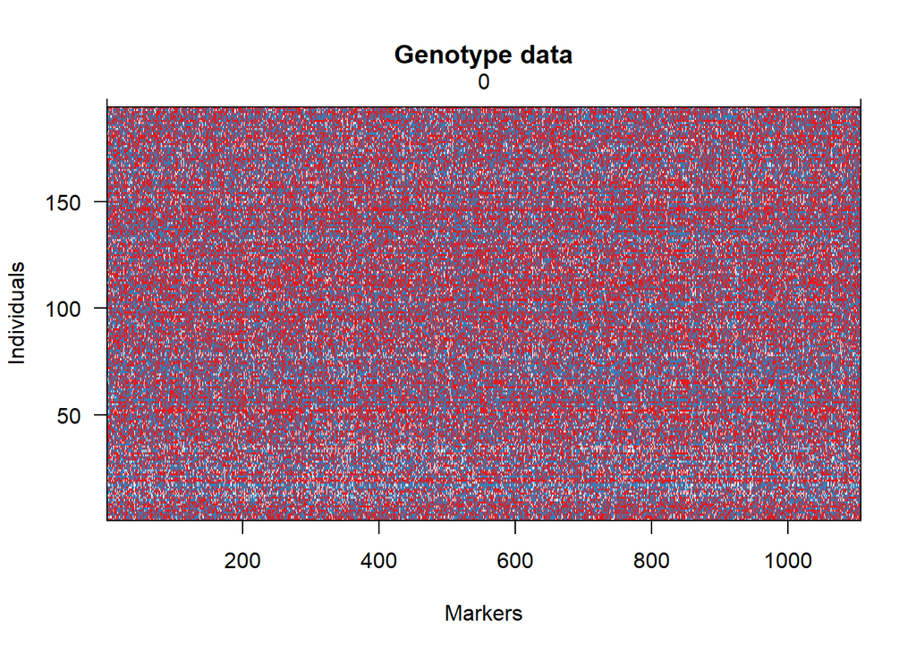

```r
geno.image(maize)
```

#Chi-squared tests for segregation distortion:

```r
gt.maize <- geno.table(maize)
head(gt.maize)
```

```
##             chr missing AA  BB    P.value
## PHM3342.31    0      12 96  86 0.45854229
## PHM14055.6    0      16 72 106 0.01082159
## PHM1511.14    0      31 77  86 0.48085106
## PZA01367.2    0       9 91  94 0.82543163
## PZA03699.1    0      13 83  98 0.26487561
## PHM14104.23   0      24 86  84 0.87808837
```

```r
table(gt.maize$P.value < 0.05)
```

```
##
## FALSE  TRUE
##   788   318
```

```r
table(gt.maize$P.value < 0.05/totmar(maize))
```

```
##
## FALSE
##  1106
```

#Two-point recombination fraction calculation:

```r
maize <- est.rf(maize)
dim(maize$rf)
```

```
## [1] 1106 1106
```

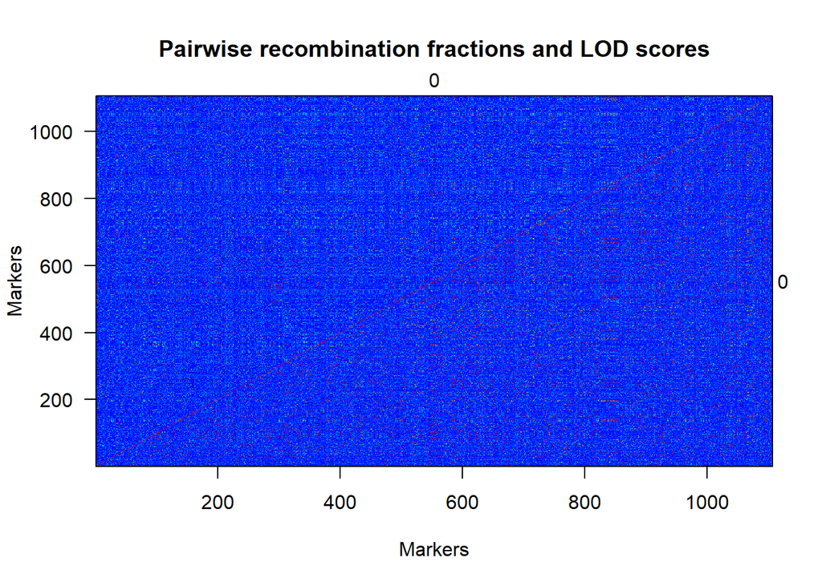

```r
plotRF(maize, col.scheme = "redblue")
```

The heatmap indicated that both the r estimates (above diagonal) and LOD scores (below diagonal) shows more blue, colder colors for non-linked markers (i.e. r≈0.5 and low LOD), and more red, warmer colors for the linked markers (i.e. r<0.5 and high LOD).

Once we have the pairwise recombination fraction estimates, we can try to see which markers are in the same linkage group. In order to do so, we need to provide the maximum recombination fraction (max.rf argument) and minimum LOD score (min.lod argument). This values are provided to the function formLinkageGroups() and they are used to see whether two markers are linked or not while avoiding false positives. We will show where these values come from, but you can use them directly in your analysis.

For max.rf, we can use something around 0.38, which is the value maximum recombination fraction of 0.50 when converted via Kosambi map function:

$$m_{ij} = \frac{1}{4} \log{\left(\frac{1 + 2r_{ij}}{1 - 2r_{ij}}\right)}$$
A recombination fraction as big as 0.50 means that two markers are independently segregating (i.e. these two markers are not linked). See below:

```r
max.rf <- 0.38
kosambi <- function(r) (1/4)*log((1+(2*r))/(1-(2*r)))
kosambi(r = max.rf)
```

```
## [1] 0.4981075
```

# Partition markers into linkage groups:

For min.lod, we can run Bonferroni correction on the number of tests that we have to perform in order to evaluate marker linkage. The number of tests is the number of marker pairs that we have in our data.

```r
(M <- totmar(maize)) # number of markers
```

```
## [1] 1106
```

```r
(num.pair <- choose(M, 2)) # number of marker pairs
```

```
## [1] 611065
```

```r
(min.lrt <- qchisq(1-(0.05/num.pair), 1)) # min LRT to consider two markers linked
```

```
## [1] 28.7624
```

```r
(min.lod <- 0.2172 * min.lrt) # conversion of LRT to LOD
```

```
## [1] 6.247193
```

Now, it is time to see how many linkage groups we have. First, we run the function formLinkageGroups() with reorgMarkers = FALSE just to see how the markers get distributed along the formed linkage groups:

```r
lg <- formLinkageGroups(maize, max.rf = 0.38, min.lod = 6.25, reorgMarkers = F)
table(lg[,2])
```

```
##
##   1   2   3   4   5   6   7   8   9  10
## 175 139 130 127 111 106  85  78  78  77
```

We note that there are 10 linkage groups (as expected for maize). Now, we can use reorgMarkers = TRUE and update our cross object named maize with each marker numbered according to the linkage group it belongs:

```r
maize <- formLinkageGroups(maize, max.rf = 0.38, min.lod = 6.25, reorgMarkers = TRUE)
summary(maize)
```

```
##     RI strains via selfing
##
##     No. individuals:    194
##
##     No. phenotypes:     35
##     Percent phenotyped: 100
##
##     No. chromosomes:    10
##         Autosomes:      1 2 3 4 5 6 7 8 9 10
##
##     Total markers:      1106
##     No. markers:        175 139 130 127 111 106 85 78 78 77
##     Percent genotyped:  91.5
##     Genotypes (%):      AA:50.1  BB:49.9
```

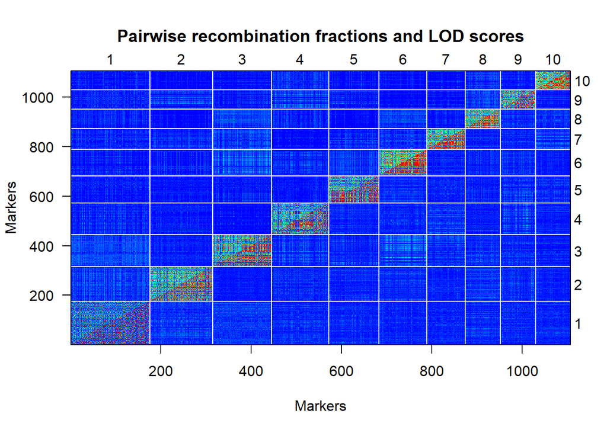

```r
plotRF(maize, col.scheme = "redblue")
```

The heatmap shows grouped but not yet ordered markers within each linkage group. #Marker ordering We are going to use the MDS algorithm and it is faster and usually more accurate.

```r
library(mappoly)
getMDSorder <- function(cross, chr) {
    markers <- match(names(cross$geno[[chr]]$map), colnames(cross$rf))
    mat <- cross$rf[markers, markers]
    rec.mat <- lod.mat <- matrix(rep(NA, length(markers)^2), nrow = length(markers))
    colnames(rec.mat) <- colnames(lod.mat) <- rownames(rec.mat) <- rownames(lod.mat) <- colnames(mat)
    lod.mat[upper.tri(lod.mat)] <- mat[upper.tri(mat)]
    lod.mat[lower.tri(lod.mat)] <- t(lod.mat)[lower.tri(lod.mat)]  #; image(lod.mat)
    rec.mat[lower.tri(rec.mat)] <- mat[lower.tri(mat)]
    rec.mat[upper.tri(rec.mat)] <- t(rec.mat)[upper.tri(rec.mat)]  #; image(rec.mat)
    input.mat <- NULL
    input.mat$rec.mat <- rec.mat
    input.mat$lod.mat <- lod.mat
    mds.map <- mappoly::mds_mappoly(input.mat)
    mds.ord <- match(as.character(mds.map$locimap$locus), colnames(mat))
    return(mds.ord)
}
```

#We’ll create a new object called maize.mds which is a copy of our original cross object maize, so that we can update the ordering within maize.mds only. In addition, we’ll create an empty object called loglik.mds to store the log-likelihood of the orderings obtained using MDS:

```r
maize.mds <- maize
loglik.mds <- c()
#Linkage group 1
c <- 1
mds.ord <- getMDSorder(cross = maize.mds, chr = c)
```

```
## Stress: 0.73308
## Mean Nearest Neighbour Fit: 3.96823
```

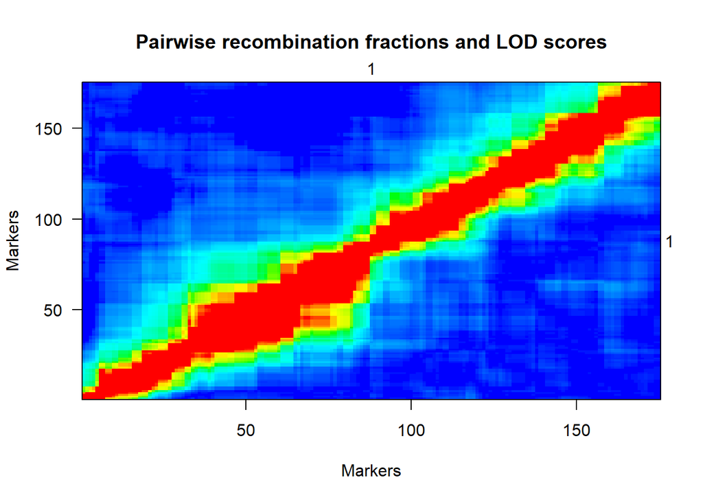

```r
maize.mds <- switch.order(cross = maize.mds, chr=c, order=mds.ord, maxit = 10000, tol=1e-5)
plotRF(maize.mds, chr=c, col.scheme = "redblue")
```

```
## Stress: 0.73308
## Mean Nearest Neighbour Fit: 3.96823
```

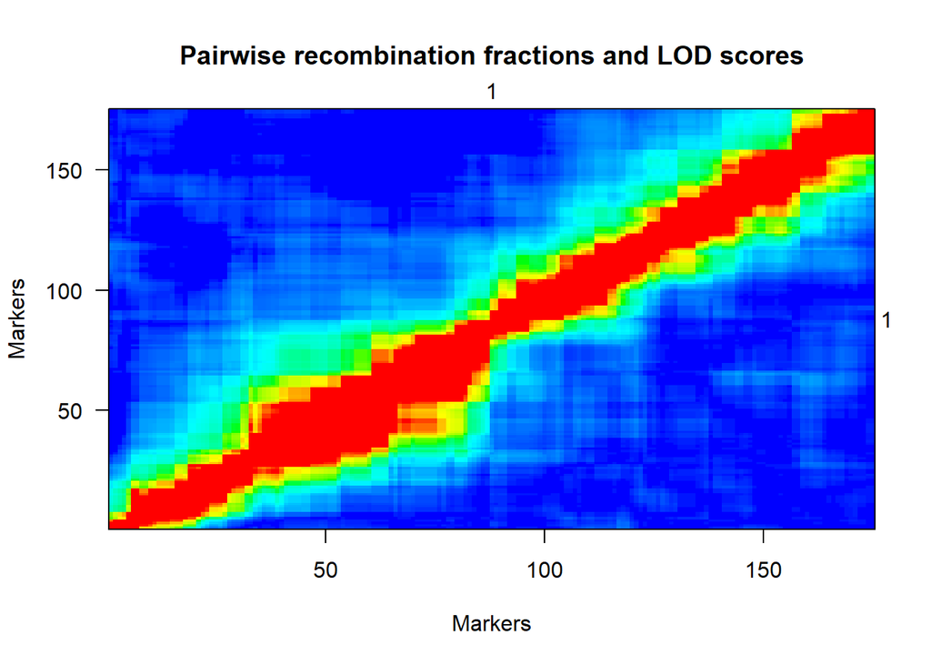

```
## Stress: 0.22549
## Mean Nearest Neighbour Fit: 3.21934
```

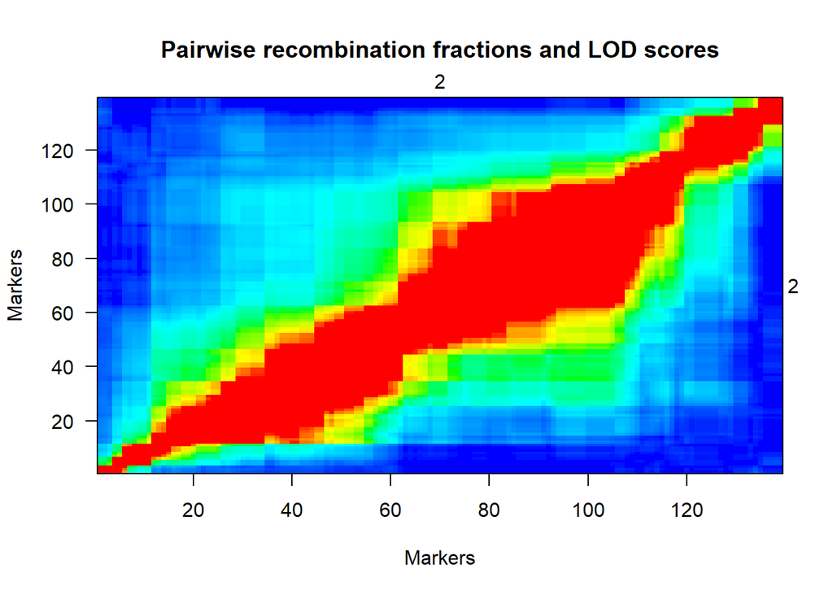

```
## Stress: 0.22009
## Mean Nearest Neighbour Fit: 2.79836
```

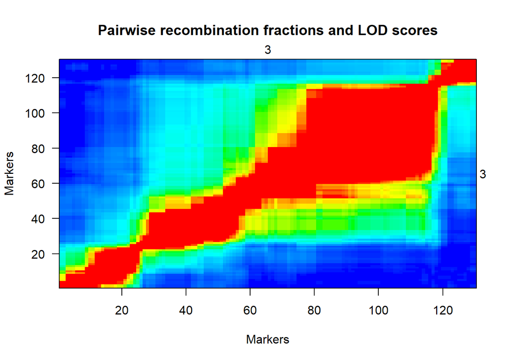

```
## Stress: 0.51126
## Mean Nearest Neighbour Fit: 3.71424
```

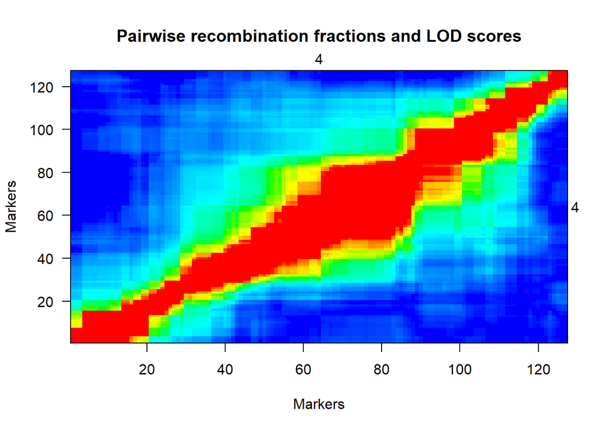

```
## Stress: 0.28999
## Mean Nearest Neighbour Fit: 3.61105
```

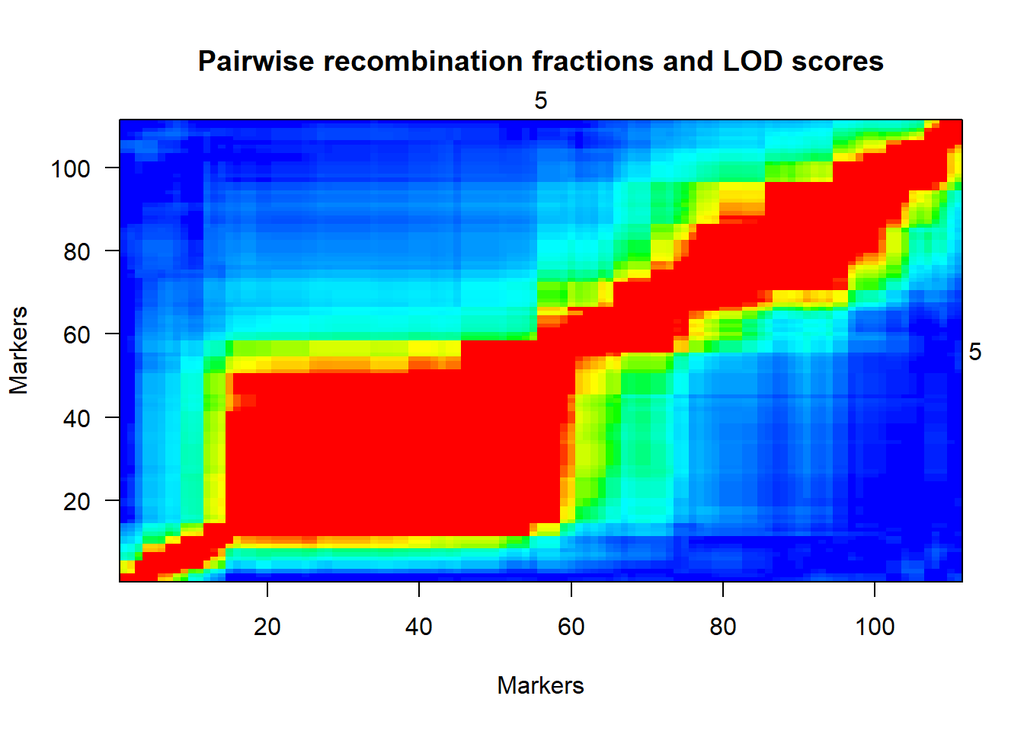

```
## Stress: 0.27475
## Mean Nearest Neighbour Fit: 3.28282
```

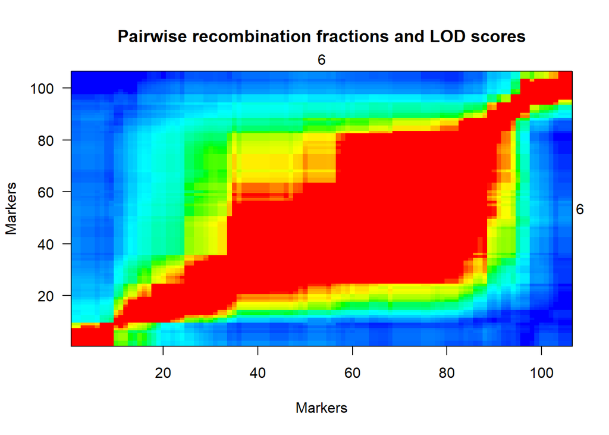

```
## Stress: 0.23831
## Mean Nearest Neighbour Fit: 3.91336
```

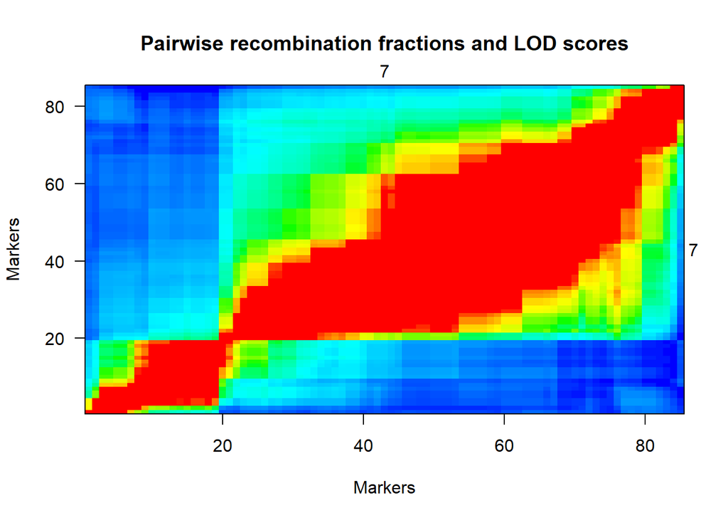

```
## Stress: 0.28662
## Mean Nearest Neighbour Fit: 3.4025
```

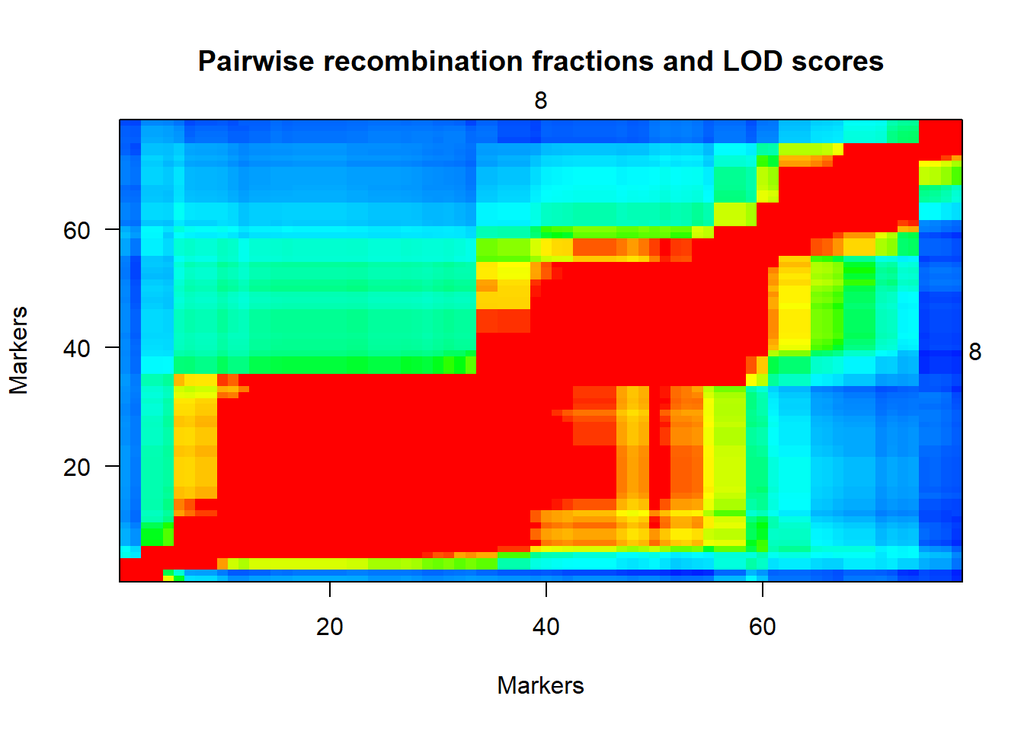

```
## Stress: 0.28815
## Mean Nearest Neighbour Fit: 3.37133
```

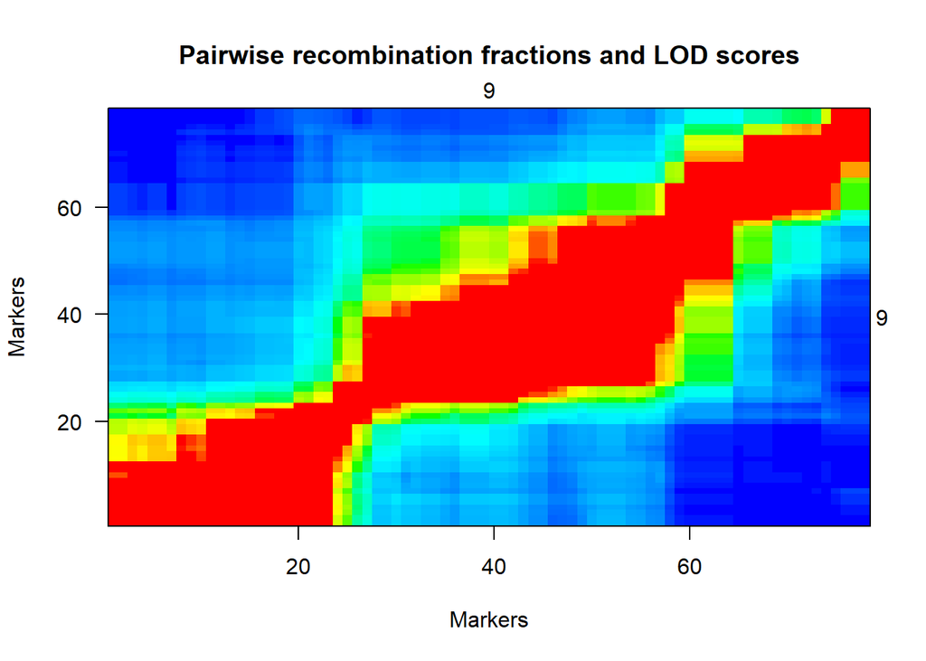

```
## Stress: 0.25074
## Mean Nearest Neighbour Fit: 3.22371
```

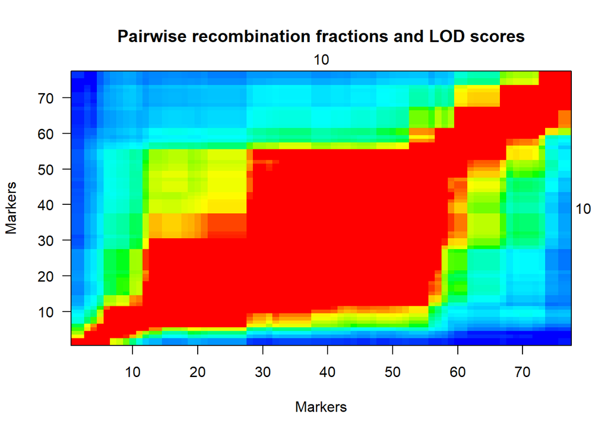

```r
# Loop through all linkage groups (assuming there are 10 linkage groups)
# Create a new object for maize and an empty vector for log-likelihoods
maize.mds <- maize
loglik.mds <- c()
for (c in 1:10) {
  # Get MDS order for the current linkage group
  mds.ord <- getMDSorder(cross = maize.mds, chr = c)

  # Switch order based on MDS ordering
  maize.mds <- switch.order(cross = maize.mds, chr = c, order = mds.ord, maxit = 10000, tol = 1e-5)

  # Plot RF for the current linkage group
  plotRF(maize.mds, chr = c, col.scheme = "redblue")

  # Pull map and log-likelihood for the current linkage group
  pull.map(maize.mds, chr = c)
  loglik.mds[c] <- attr(maize.mds$geno[[c]]$map, "loglik")
}
```

Final map:

```r
# Display summary table of the map with log-likelihoods
knitr::kable(cbind(summaryMap(maize.mds), log.likelihood = c(loglik.mds, sum(loglik.mds))))
```

|  | n.mar | length | ave.spacing | max.spacing | log.likelihood |
| --- | --- | --- | --- | --- | --- |
| 1 | 175 | 207.43697 | 1.192166 | 10.431475 | -2584.273 |
| 2 | 139 | 140.37112 | 1.017182 | 13.137785 | -1802.302 |
| 3 | 130 | 133.02244 | 1.031182 | 13.155448 | -1686.443 |
| 4 | 127 | 154.22512 | 1.224009 | 10.115212 | -1996.788 |
| 5 | 111 | 140.89204 | 1.280837 | 13.338671 | -1765.022 |
| 6 | 106 | 121.03452 | 1.152710 | 18.102868 | -1508.223 |
| 7 | 85 | 107.33072 | 1.277747 | 17.346341 | -1315.862 |
| 8 | 78 | 131.35630 | 1.705926 | 32.145874 | -1217.591 |
| 9 | 78 | 95.84836 | 1.244784 | 10.937486 | -1207.605 |
| 10 | 77 | 81.37832 | 1.070767 | 9.103785 | -1055.386 |
| overall | 1106 | 1312.89591 | 1.197898 | 32.145874 | -16139.496 |

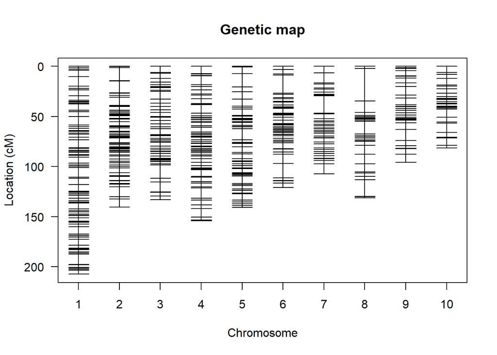

```r
# Plot the overall map
plotMap(maize.mds)
```

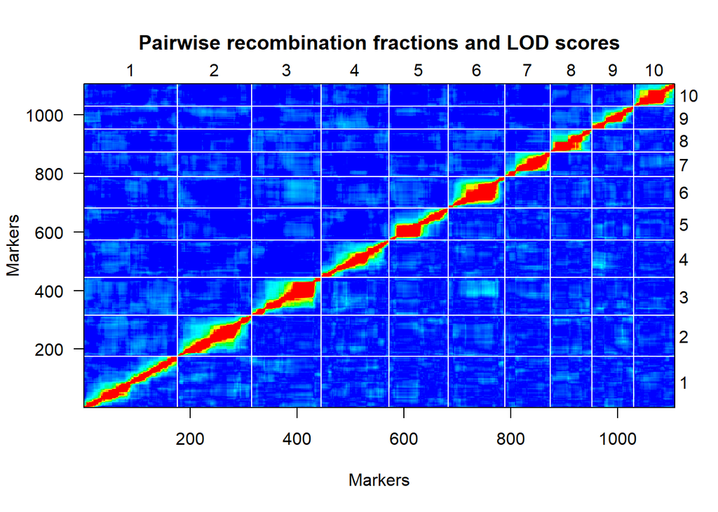

```r
plotRF(maize.mds, col.scheme = "redblue")
```

```r
# Save the workspace image
save.image("maize_mds.RData")
```

## QTL mapping

### Single marker analysis (SMA)

```r
# Step 1: Calculate genotype probabilities
# 'calc.genoprob' calculates the conditional genotype probabilities at each position.
# 'step = 1' defines the step size for the calculation (i.e., every 1 cM).
maize.mds <- calc.genoprob(cross = maize.mds, step = 1)
# Perform single marker analysis (SMA) using the method "mr" (marker regression).
maize.mr <- scanone(maize.mds, pheno.col = "PlantHeight", method = "mr")
# Summarize the significant markers from the scanone results.
# Displays a table with chromosome, position, and LOD score (logarithm of the odds).
summary(maize.mr)
```

```
##             chr    pos   lod
## PHM3034.3     1 154.61 6.287
## PZA02667.1    2  44.77 1.472
## PHM1745.16    3  86.90 4.075
## PZA03559.1    4  38.28 1.721
## fea2.3        5  55.81 1.933
## PHM2350.17    6  73.67 6.448
## PZA00840.1    7  59.34 7.799
## PHM7898.10    8 105.52 1.725
## PZA00543.12   9   9.69 2.194
## PZA02049.1   10  71.19 0.473
```

```r
# Run permutation tests to establish LOD thresholds.
# The function performs 'n.perm = 1000' permutations to generate a null distribution.
maize.perm.mr <- scanone(maize.mds, pheno.col = "PlantHeight", method = "mr", n.perm = 1000)
```

[output not shown]

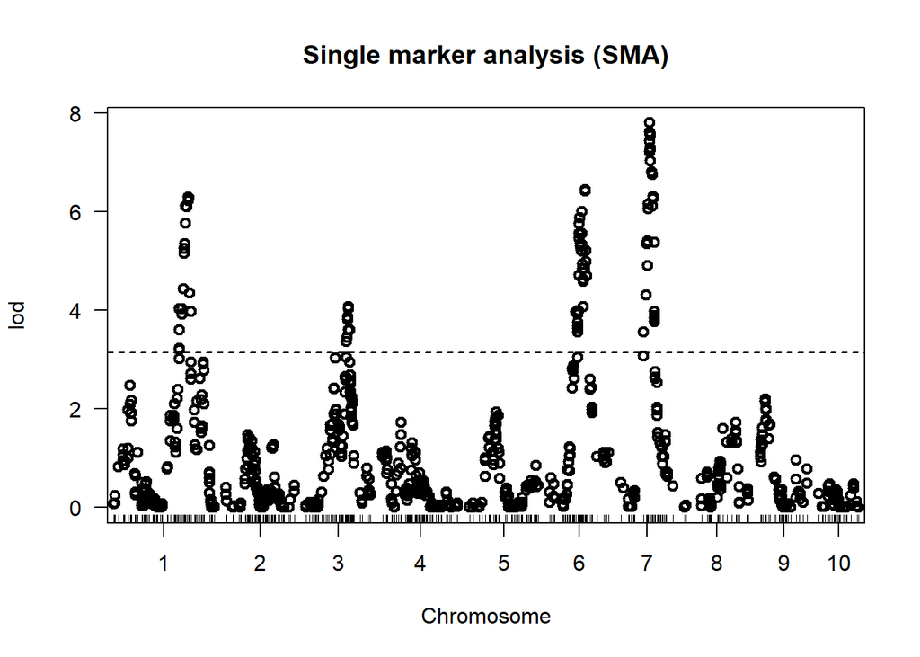

```r
# Plot the results of the single marker analysis.
# The LOD score for each marker is plotted along the genome.
plot(maize.mr, type = "p", main = "Single marker analysis (SMA)")
# Add a significance threshold line to the plot based on permutation tests.
add.threshold(maize.mr, perms = maize.perm.mr, alpha = 0.05, lty = 2, col = "black")
```

### Interval mapping (IM)

```r
# Perform interval mapping (IM) using the Haley-Knott regression method (method = "hk").
maize.im <- scanone(cross = maize.mds, pheno.col = "PlantHeight", method = "hk")
# Summarize the results of the interval mapping.
summary(maize.im)
```

```
##             chr    pos   lod
## c1.loc153     1 153.00 6.575
## PZA02667.1    2  44.77 1.772
## PZA02474.1    3  86.90 3.285
## PZA03559.1    4  38.28 1.582
## c5.loc58      5  58.00 2.309
## c6.loc62      6  62.00 6.190
## c7.loc60      7  60.00 7.030
## c8.loc100     8 100.00 1.523
## PZA00543.12   9   9.69 1.954
## c10.loc33    10  33.00 0.437
```

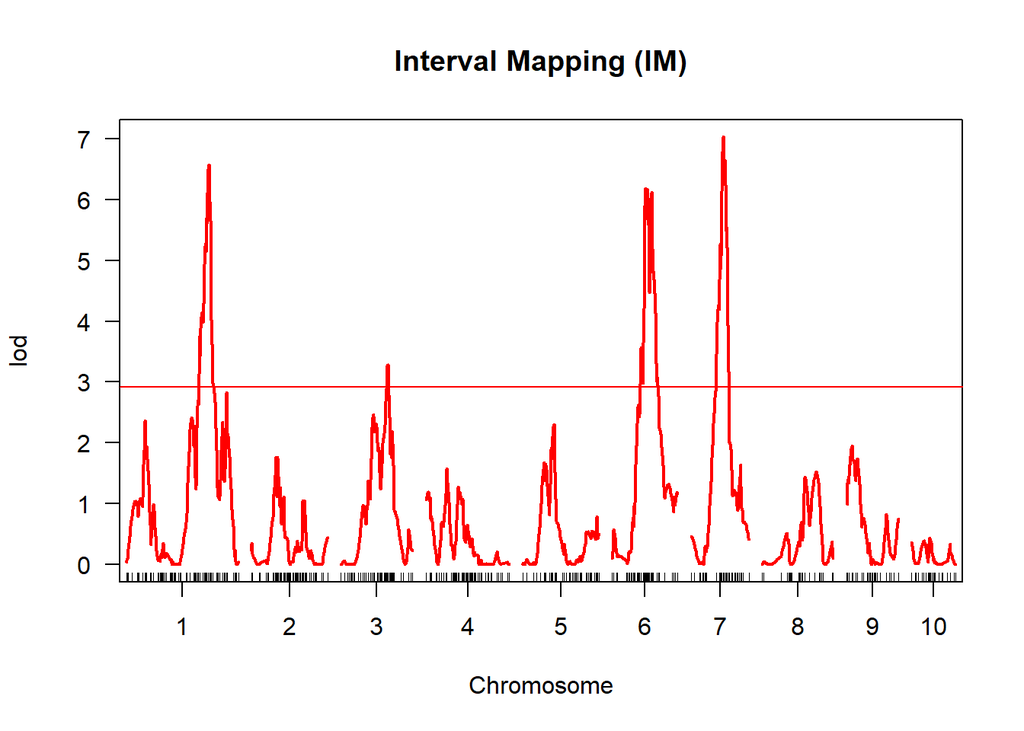

```r
# Perform permutation tests to calculate a significance threshold for QTL detection.
# n.perm = 1000 indicates that 1000 permutations are performed to assess the statistical significance of QTL.
# verbose = FALSE suppresses detailed output during the permutation process.
maize.perm.im <- scanone(cross = maize.mds, pheno.col = "PlantHeight", method = "hk", n.perm = 1000, verbose = FALSE)
# Plot the interval mapping results, with the LOD scores plotted against chromosomal positions.
plot(maize.im, col = "red", main = "Interval Mapping (IM)")

# Add a significance threshold line to the plot based on the permutation results.
add.threshold(maize.im, perms = maize.perm.im, alpha = 0.05, col = "red")
```

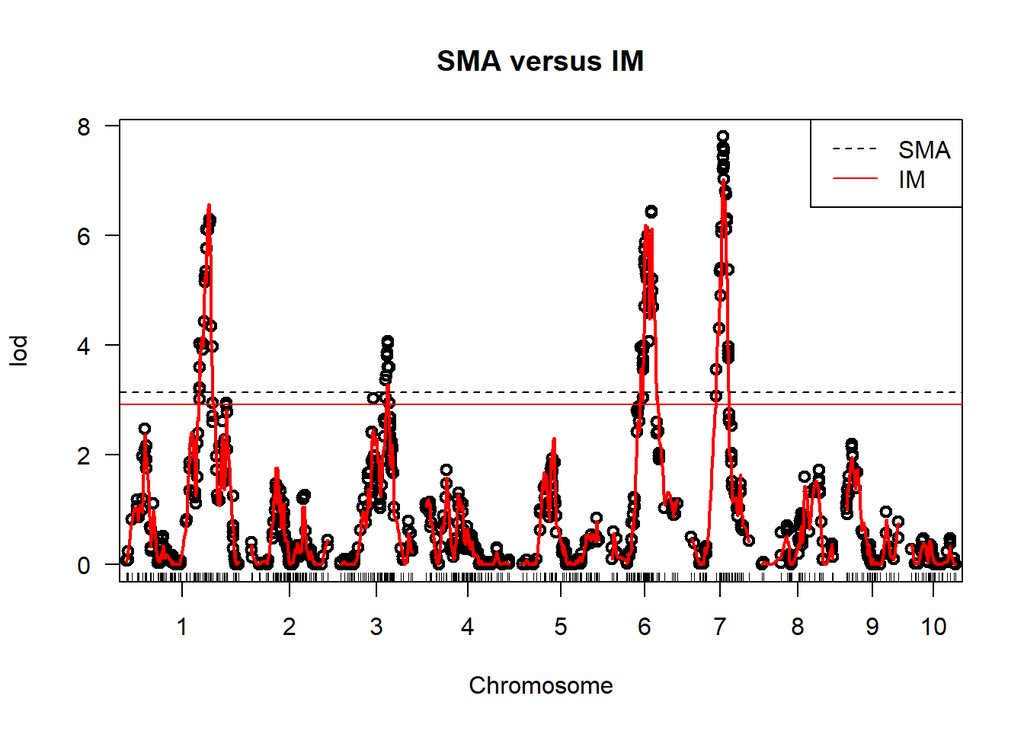

```r
# Plot the Single Marker Analysis (SMA) and Interval Mapping (IM) results
# 'type = c("p", "l")' specifies points for SMA and lines for IM
# 'col = c("black", "red")' sets the color for SMA as black and IM as red
plot(maize.mr, maize.im, type = c("p", "l"), col = c("black", "red"), main = "SMA versus IM")
# Add significance threshold to the SMA plot
add.threshold(maize.mr, perms = maize.perm.mr, alpha = 0.05, lty = 2, col = "black")
# Add significance threshold to the IM plot
add.threshold(maize.im, perms = maize.perm.im, alpha = 0.05, col = "red")
# Add a legend to the plot
legend("topright", legend = c("SMA", "IM"), lty = c(2, 1), col = c("black", "red"))
```

```r
maize.im.sig <- summary(maize.im, perms = maize.perm.im, alpha = 0.05)
maize.im.sig
```

```
##            chr   pos  lod
## c1.loc153    1 153.0 6.58
## PZA02474.1   3  86.9 3.29
## c6.loc62     6  62.0 6.19
## c7.loc60     7  60.0 7.03
```

### Composite interval mapping (CIM)

```r
# CIM with a 10 cM window
maize.cim10 <- cim(
  cross = maize.mds,               # The maize cross data
  pheno.col = "PlantHeight",        # Phenotype column for Plant Height
  method = "hk",                    # Using Haley-Knott regression
  n.marcovar = 2 * sqrt(nind(maize.mds)), # Number of marker covariates
  window = 10                       # Window size set to 10 cM
)

# CIM with a 15 cM window
maize.cim15 <- cim(
  cross = maize.mds,
  pheno.col = "PlantHeight",
  method = "hk",
  n.marcovar = 2 * sqrt(nind(maize.mds)),
  window = 15                       # Window size set to 15 cM
)

# CIM with a 20 cM window
maize.cim20 <- cim(
  cross = maize.mds,
  pheno.col = "PlantHeight",
  method = "hk",
  n.marcovar = 2 * sqrt(nind(maize.mds)),
  window = 20                       # Window size set to 20 cM
)

# CIM with an infinite window (considering the entire chromosome)
maize.cimInf <- cim(
  cross = maize.mds,
  pheno.col = "PlantHeight",
  method = "hk",
  n.marcovar = 2 * sqrt(nind(maize.mds)),
  window = Inf                      # Window size set to cover the entire chromosome
)
```

```r
summary(maize.cim10)
```

```
##             chr    pos   lod
## c1.loc146     1 146.00  8.95
## PZA01265.1    2  47.36  3.86
## PHM1745.16    3  86.90  4.75
## PZA00902.1    4   7.48  5.21
## c5.loc34      5  34.00  1.84
## c6.loc70      6  70.00  9.26
## c7.loc60      7  60.00 25.88
## c8.loc100     8 100.00  3.40
## c9.loc10      9  10.00  4.46
## PHM15331.16  10  22.46  2.97
```

```r
summary(maize.cim15)
```

```
##            chr    pos    lod
## PZA01652.1   1  33.69  9.859
## PZA03324.1   2  59.56  6.330
## c3.loc86     3  86.00  3.265
## c4.loc2      4   2.00  2.998
## PHM1184.26   5   7.08  3.716
## c6.loc73     6  73.00 14.929
## PZA00060.2   7  59.34 13.103
## c8.loc104    8 104.00  0.769
## c9.loc17     9  17.00  3.747
## c10.loc24   10  24.00  2.652
```

```r
summary(maize.cim20)
```

```
##            chr   pos   lod
## c1.loc146    1 146.0  9.56
## c2.loc57     2  57.0  5.23
## c3.loc87     3  87.0  4.42
## c4.loc3      4   3.0  3.98
## c5.loc7      5   7.0  4.47
## PZA00758.1   6  73.7  5.82
## c7.loc63     7  63.0 19.90
## c8.loc45     8  45.0  1.86
## c9.loc18     9  18.0  2.30
## c10.loc26   10  26.0  4.44
```

```r
summary(maize.cimInf)
```

```
##            chr    pos   lod
## c1.loc146    1 146.00 11.69
## PZA03172.3   2  55.32  3.32
## c3.loc88     3  88.00  4.33
## c4.loc1      4   1.00  4.68
## PHM1184.26   5   7.08  3.25
## PZA00758.1   6  73.67 15.63
## c7.loc60     7  60.00 21.96
## c8.loc90     8  90.00  1.85
## PHM8909.12   9  16.48  2.29
## PHM3765.7   10  18.77  4.68
```

```r
maize.perm.cim <- cim(cross = maize.mds, pheno.col = "PlantHeight", method = "hk",
    n.marcovar = 2 * sqrt(nind(maize.mds)), window = Inf, n.perm = 1000)
summary(maize.perm.cim, alpha = 0.05)
```

```
## LOD thresholds (1000 permutations)
##    [,1]
## 5% 7.14
```

```r
summary(maize.cim10, perms = maize.perm.cim, alpha = 0.05)
```

```
##           chr pos   lod
## c1.loc146   1 146  8.95
## c6.loc70    6  70  9.26
## c7.loc60    7  60 25.88
```

```r
summary(maize.cim15, perms = maize.perm.cim, alpha = 0.05)
```

```
##            chr  pos   lod
## PZA01652.1   1 33.7  9.86
## c6.loc73     6 73.0 14.93
## PZA00060.2   7 59.3 13.10
```

```r
summary(maize.cim20, perms = maize.perm.cim, alpha = 0.05)
```

```
##           chr pos   lod
## c1.loc146   1 146  9.56
## c7.loc63    7  63 19.90
```

```r
summary(maize.cimInf, perms = maize.perm.cim, alpha = 0.05)
```

```
##            chr   pos  lod
## c1.loc146    1 146.0 11.7
## PZA00758.1   6  73.7 15.6
## c7.loc60     7  60.0 22.0
```

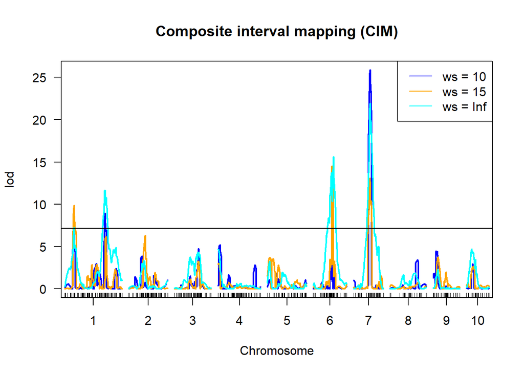

```r
plot(maize.cim10, maize.cim15, maize.cimInf, col = c("blue", "orange", "cyan"), main = "Composite interval mapping (CIM)")
add.threshold(maize.cim10, perms = maize.perm.cim, alpha = 0.05)
legend("topright", legend = c("ws = 10", "ws = 15", "ws = Inf"), lty = 1, col = c("blue",
    "orange", "cyan"))
```

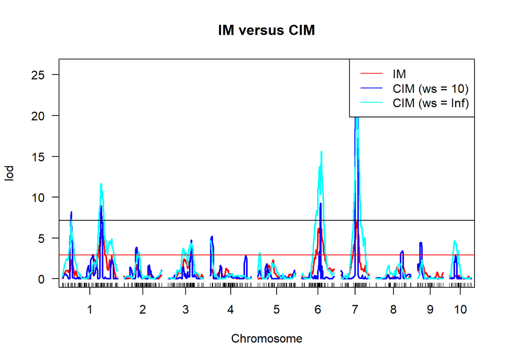

```r
plot(maize.im, maize.cim10, maize.cimInf, col = c("red", "blue", "cyan"), main = "IM versus CIM")
add.threshold(maize.cim10, perms = maize.perm.cim, alpha = 0.05)
add.threshold(maize.im, perms = maize.perm.im, alpha = 0.05, col = "red")
legend("topright", legend = c("IM", "CIM (ws = 10)", "CIM (ws = Inf)"), lty = 1,
    col = c("red", "blue", "cyan"))
```

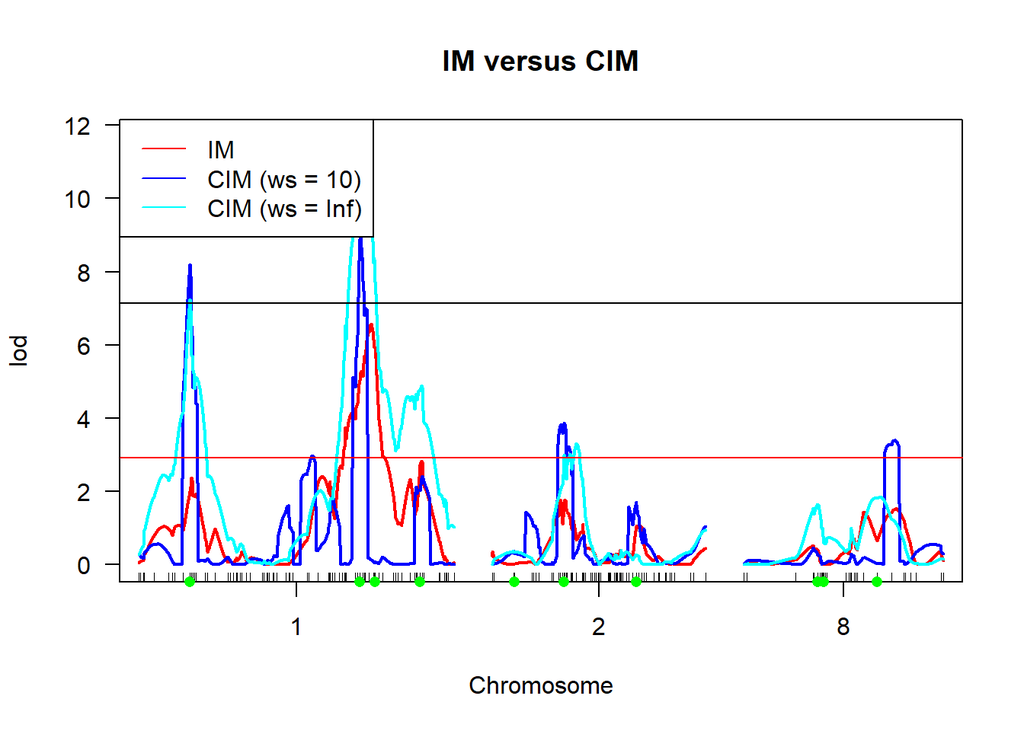

```r
plot(maize.im, maize.cim10, maize.cimInf, col = c("red", "blue", "cyan"), chr = c(1,
    2, 8), main = "IM versus CIM")
add.threshold(maize.im, perms = maize.perm.im, alpha = 0.05, col = "red")
add.threshold(maize.cim10, perms = maize.perm.cim, alpha = 0.05, col = "black")
add.cim.covar(maize.cimInf, chr = c(1, 2, 8), col = "green")
legend("topleft", legend = c("IM", "CIM (ws = 10)", "CIM (ws = Inf)"), lty = 1, col = c("red",
    "blue", "cyan"))
```

```r
maize.cim.sig <- summary(maize.cim10, perms = maize.perm.cim, alpha = 0.05)
maize.cim.sig
```

```
##           chr pos   lod
## c1.loc146   1 146  8.95
## c6.loc70    6  70  9.26
## c7.loc60    7  60 25.88
```

```r
peak.markers <- which(maize.cim10$lod[maize.cim10$chr == 1] > 7.39)
maize.cim10$lod[peak.markers]
```

```
##  [1] 7.903058 8.203960 7.861737 8.302144 8.894306 8.894307 8.948090 8.389672
##  [9] 7.742851 7.466602
```

```r
maize.cim10$pos[peak.markers]
```

```
##  [1]  33.00000  33.69397  34.00000 145.00000 145.35165 145.35165 146.00000
##  [8] 147.00000 147.59037 148.00000
```